# Risk Factor Analysis

## Outcome Variable

**Outcome Variable:** ever_wasted

## Predictor Variables

**Intervention Variable:** gagebrth

**Adjustment Set:**

unadjusted

## Stratifying Variables

The analysis was stratified on these variable(s):

- agecat
- studyid
- country

## Data Summary

| agecat | studyid | country | gagebrth | ever_wasted | n_cell | n |
| --- | --- | --- | --- | --- | --- | --- |
| 0-24 months (no birth wast) | ki1000108-CMC-V-BCS-2002 | INDIA | Full or late term | 0 | 123 | 348 |
| 0-24 months (no birth wast) | ki1000108-CMC-V-BCS-2002 | INDIA | Full or late term | 1 | 90 | 348 |
| 0-24 months (no birth wast) | ki1000108-CMC-V-BCS-2002 | INDIA | Preterm | 0 | 25 | 348 |
| 0-24 months (no birth wast) | ki1000108-CMC-V-BCS-2002 | INDIA | Preterm | 1 | 27 | 348 |
| 0-24 months (no birth wast) | ki1000108-CMC-V-BCS-2002 | INDIA | Early term | 0 | 46 | 348 |
| 0-24 months (no birth wast) | ki1000108-CMC-V-BCS-2002 | INDIA | Early term | 1 | 37 | 348 |
| 0-24 months (no birth wast) | ki1000108-IRC | INDIA | Full or late term | 0 | 121 | 389 |
| 0-24 months (no birth wast) | ki1000108-IRC | INDIA | Full or late term | 1 | 128 | 389 |
| 0-24 months (no birth wast) | ki1000108-IRC | INDIA | Preterm | 0 | 16 | 389 |
| 0-24 months (no birth wast) | ki1000108-IRC | INDIA | Preterm | 1 | 26 | 389 |
| 0-24 months (no birth wast) | ki1000108-IRC | INDIA | Early term | 0 | 44 | 389 |
| 0-24 months (no birth wast) | ki1000108-IRC | INDIA | Early term | 1 | 54 | 389 |
| 0-24 months (no birth wast) | ki1000109-EE | PAKISTAN | Full or late term | 0 | 19 | 377 |
| 0-24 months (no birth wast) | ki1000109-EE | PAKISTAN | Full or late term | 1 | 6 | 377 |
| 0-24 months (no birth wast) | ki1000109-EE | PAKISTAN | Preterm | 0 | 132 | 377 |
| 0-24 months (no birth wast) | ki1000109-EE | PAKISTAN | Preterm | 1 | 111 | 377 |
| 0-24 months (no birth wast) | ki1000109-EE | PAKISTAN | Early term | 0 | 61 | 377 |
| 0-24 months (no birth wast) | ki1000109-EE | PAKISTAN | Early term | 1 | 48 | 377 |
| 0-24 months (no birth wast) | ki1000304b-SAS-CompFeed | INDIA | Full or late term | 0 | 7 | 457 |
| 0-24 months (no birth wast) | ki1000304b-SAS-CompFeed | INDIA | Full or late term | 1 | 4 | 457 |
| 0-24 months (no birth wast) | ki1000304b-SAS-CompFeed | INDIA | Preterm | 0 | 269 | 457 |
| 0-24 months (no birth wast) | ki1000304b-SAS-CompFeed | INDIA | Preterm | 1 | 143 | 457 |
| 0-24 months (no birth wast) | ki1000304b-SAS-CompFeed | INDIA | Early term | 0 | 21 | 457 |
| 0-24 months (no birth wast) | ki1000304b-SAS-CompFeed | INDIA | Early term | 1 | 13 | 457 |
| 0-24 months (no birth wast) | ki1017093c-NIH-Crypto | BANGLADESH | Full or late term | 0 | 152 | 754 |
| 0-24 months (no birth wast) | ki1017093c-NIH-Crypto | BANGLADESH | Full or late term | 1 | 16 | 754 |
| 0-24 months (no birth wast) | ki1017093c-NIH-Crypto | BANGLADESH | Preterm | 0 | 214 | 754 |
| 0-24 months (no birth wast) | ki1017093c-NIH-Crypto | BANGLADESH | Preterm | 1 | 47 | 754 |
| 0-24 months (no birth wast) | ki1017093c-NIH-Crypto | BANGLADESH | Early term | 0 | 280 | 754 |
| 0-24 months (no birth wast) | ki1017093c-NIH-Crypto | BANGLADESH | Early term | 1 | 45 | 754 |

[output cut: 186 more lines]

The following strata were considered:

- agecat: 0-24 months (no birth wast), studyid: ki1000108-CMC-V-BCS-2002, country: INDIA
- agecat: 0-24 months (no birth wast), studyid: ki1000108-IRC, country: INDIA
- agecat: 0-24 months (no birth wast), studyid: ki1000109-EE, country: PAKISTAN
- agecat: 0-24 months (no birth wast), studyid: ki1000304b-SAS-CompFeed, country: INDIA
- agecat: 0-24 months (no birth wast), studyid: ki1017093c-NIH-Crypto, country: BANGLADESH
- agecat: 0-24 months (no birth wast), studyid: ki1066203-TanzaniaChild2, country: TANZANIA, UNITED REPUBLIC OF
- agecat: 0-24 months (no birth wast), studyid: ki1101329-Keneba, country: GAMBIA
- agecat: 0-24 months (no birth wast), studyid: ki1119695-PROBIT, country: BELARUS
- agecat: 0-24 months (no birth wast), studyid: ki1135781-COHORTS, country: GUATEMALA
- agecat: 0-24 months (no birth wast), studyid: ki1135781-COHORTS, country: INDIA
- agecat: 0-24 months (no birth wast), studyid: ki1135781-COHORTS, country: PHILIPPINES
- agecat: 0-24 months (no birth wast), studyid: kiGH5241-JiVitA-3, country: BANGLADESH
- agecat: 0-6 months (no birth wast), studyid: ki1000108-CMC-V-BCS-2002, country: INDIA
- agecat: 0-6 months (no birth wast), studyid: ki1000108-IRC, country: INDIA
- agecat: 0-6 months (no birth wast), studyid: ki1000109-EE, country: PAKISTAN
- agecat: 0-6 months (no birth wast), studyid: ki1000304b-SAS-CompFeed, country: INDIA
- agecat: 0-6 months (no birth wast), studyid: ki1017093c-NIH-Crypto, country: BANGLADESH
- agecat: 0-6 months (no birth wast), studyid: ki1066203-TanzaniaChild2, country: TANZANIA, UNITED REPUBLIC OF
- agecat: 0-6 months (no birth wast), studyid: ki1101329-Keneba, country: GAMBIA
- agecat: 0-6 months (no birth wast), studyid: ki1119695-PROBIT, country: BELARUS
- agecat: 0-6 months (no birth wast), studyid: ki1135781-COHORTS, country: GUATEMALA
- agecat: 0-6 months (no birth wast), studyid: ki1135781-COHORTS, country: INDIA
- agecat: 0-6 months (no birth wast), studyid: ki1135781-COHORTS, country: PHILIPPINES
- agecat: 0-6 months (no birth wast), studyid: kiGH5241-JiVitA-3, country: BANGLADESH
- agecat: 6-24 months, studyid: ki1000108-CMC-V-BCS-2002, country: INDIA
- agecat: 6-24 months, studyid: ki1000108-IRC, country: INDIA
- agecat: 6-24 months, studyid: ki1000109-EE, country: PAKISTAN
- agecat: 6-24 months, studyid: ki1000304b-SAS-CompFeed, country: INDIA
- agecat: 6-24 months, studyid: ki1017093c-NIH-Crypto, country: BANGLADESH
- agecat: 6-24 months, studyid: ki1066203-TanzaniaChild2, country: TANZANIA, UNITED REPUBLIC OF
- agecat: 6-24 months, studyid: ki1101329-Keneba, country: GAMBIA
- agecat: 6-24 months, studyid: ki1119695-PROBIT, country: BELARUS
- agecat: 6-24 months, studyid: ki1135781-COHORTS, country: GUATEMALA
- agecat: 6-24 months, studyid: ki1135781-COHORTS, country: INDIA
- agecat: 6-24 months, studyid: ki1135781-COHORTS, country: PHILIPPINES
- agecat: 6-24 months, studyid: kiGH5241-JiVitA-3, country: BANGLADESH

### Dropped Strata

Some strata were dropped due to rare outcomes:

- agecat: 0-24 months (no birth wast), studyid: ki1000304b-SAS-CompFeed, country: INDIA
- agecat: 0-6 months (no birth wast), studyid: ki1000109-EE, country: PAKISTAN
- agecat: 0-6 months (no birth wast), studyid: ki1000304b-SAS-CompFeed, country: INDIA
- agecat: 0-6 months (no birth wast), studyid: ki1135781-COHORTS, country: GUATEMALA
- agecat: 6-24 months, studyid: ki1000109-EE, country: PAKISTAN
- agecat: 6-24 months, studyid: ki1000304b-SAS-CompFeed, country: INDIA
- agecat: 6-24 months, studyid: ki1119695-PROBIT, country: BELARUS

## Methods Detail

We’re interested in the causal parameters $E[Y_a]$ for all values of $a \in \mathcal{A}$. These parameters represent the mean outcome if, possibly contrary to fact, we intervened to set all units to have $A=a$. Under the randomization and positivity assumptions, these are identified by the statistical parameters $\psi_a=E_W[E_{Y|A,W}(Y|A=a,W)]$. In addition, we’re interested in the mean of $Y$, $E[Y]$ under no intervention (the observed mean). We will estimate these parameters by using SuperLearner to fit the relevant likelihood factors – $E_{Y|A,W}(Y|A=a,W)$ and $p(A=a|W)$, and then updating our likelihood fit using a joint TMLE.

For unadjusted analyses ($W=\{\}$), initial likelihoods were estimated using Lrnr_glm to estimate the simple $E(Y|A)$ and Lrnr_mean to estimate $p(A)$. For adjusted analyses, a small library containing Lrnr_glmnet, Lrnr_xgboost, and Lrnr_mean was used.

Having estimated these parameters, we will then use the delta method to estimate relative risks and attributable risks relative to a prespecified baseline level of $A$.

# Results Detail

## Results Plots

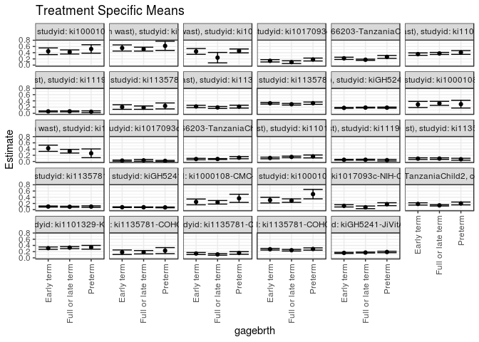

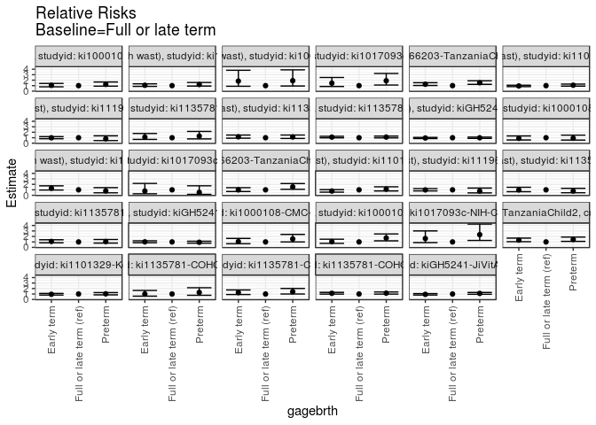

[figure not shown]

[figure not shown]

## Results Table

### Parameter: TSM

| agecat | studyid | country | intervention_level | baseline_level | estimate | ci_lower | ci_upper |
| --- | --- | --- | --- | --- | --- | --- | --- |
| 0-24 months (no birth wast) | ki1000108-CMC-V-BCS-2002 | INDIA | Full or late term | NA | 0.4225352 | 0.3561032 | 0.4889672 |
| 0-24 months (no birth wast) | ki1000108-CMC-V-BCS-2002 | INDIA | Preterm | NA | 0.5192308 | 0.3832367 | 0.6552248 |
| 0-24 months (no birth wast) | ki1000108-CMC-V-BCS-2002 | INDIA | Early term | NA | 0.4457831 | 0.3386964 | 0.5528699 |
| 0-24 months (no birth wast) | ki1000108-IRC | INDIA | Full or late term | NA | 0.5140562 | 0.4518970 | 0.5762155 |
| 0-24 months (no birth wast) | ki1000108-IRC | INDIA | Preterm | NA | 0.6190476 | 0.4719926 | 0.7661026 |
| 0-24 months (no birth wast) | ki1000108-IRC | INDIA | Early term | NA | 0.5510204 | 0.4524172 | 0.6496236 |
| 0-24 months (no birth wast) | ki1000109-EE | PAKISTAN | Full or late term | NA | 0.2400000 | 0.0723640 | 0.4076360 |
| 0-24 months (no birth wast) | ki1000109-EE | PAKISTAN | Preterm | NA | 0.4567901 | 0.3940762 | 0.5195040 |
| 0-24 months (no birth wast) | ki1000109-EE | PAKISTAN | Early term | NA | 0.4403670 | 0.3470479 | 0.5336861 |
| 0-24 months (no birth wast) | ki1017093c-NIH-Crypto | BANGLADESH | Full or late term | NA | 0.0952381 | 0.0508206 | 0.1396556 |
| 0-24 months (no birth wast) | ki1017093c-NIH-Crypto | BANGLADESH | Preterm | NA | 0.1800766 | 0.1334288 | 0.2267244 |
| 0-24 months (no birth wast) | ki1017093c-NIH-Crypto | BANGLADESH | Early term | NA | 0.1384615 | 0.1008868 | 0.1760363 |
| 0-24 months (no birth wast) | ki1066203-TanzaniaChild2 | TANZANIA, UNITED REPUBLIC OF | Full or late term | NA | 0.1732852 | 0.1533473 | 0.1932231 |
| 0-24 months (no birth wast) | ki1066203-TanzaniaChild2 | TANZANIA, UNITED REPUBLIC OF | Preterm | NA | 0.2645349 | 0.2179132 | 0.3111566 |
| 0-24 months (no birth wast) | ki1066203-TanzaniaChild2 | TANZANIA, UNITED REPUBLIC OF | Early term | NA | 0.2183236 | 0.1825675 | 0.2540797 |
| 0-24 months (no birth wast) | ki1101329-Keneba | GAMBIA | Full or late term | NA | 0.3755981 | 0.3427608 | 0.4084354 |
| 0-24 months (no birth wast) | ki1101329-Keneba | GAMBIA | Preterm | NA | 0.4062500 | 0.3460696 | 0.4664304 |
| 0-24 months (no birth wast) | ki1101329-Keneba | GAMBIA | Early term | NA | 0.3539232 | 0.3156178 | 0.3922286 |
| 0-24 months (no birth wast) | ki1119695-PROBIT | BELARUS | Full or late term | NA | 0.0619748 | 0.0470207 | 0.0769289 |
| 0-24 months (no birth wast) | ki1119695-PROBIT | BELARUS | Preterm | NA | 0.0500000 | 0.0210513 | 0.0789487 |
| 0-24 months (no birth wast) | ki1119695-PROBIT | BELARUS | Early term | NA | 0.0612546 | 0.0462867 | 0.0762225 |
| 0-24 months (no birth wast) | ki1135781-COHORTS | GUATEMALA | Full or late term | NA | 0.1818182 | 0.1280260 | 0.2356104 |
| 0-24 months (no birth wast) | ki1135781-COHORTS | GUATEMALA | Preterm | NA | 0.2368421 | 0.1411363 | 0.3325479 |
| 0-24 months (no birth wast) | ki1135781-COHORTS | GUATEMALA | Early term | NA | 0.2017544 | 0.1279919 | 0.2755169 |
| 0-24 months (no birth wast) | ki1135781-COHORTS | INDIA | Full or late term | NA | 0.1882556 | 0.1564023 | 0.2201089 |
| 0-24 months (no birth wast) | ki1135781-COHORTS | INDIA | Preterm | NA | 0.2142857 | 0.1684437 | 0.2601277 |
| 0-24 months (no birth wast) | ki1135781-COHORTS | INDIA | Early term | NA | 0.2197802 | 0.1817169 | 0.2578436 |
| 0-24 months (no birth wast) | ki1135781-COHORTS | PHILIPPINES | Full or late term | NA | 0.2910382 | 0.2645137 | 0.3175626 |
| 0-24 months (no birth wast) | ki1135781-COHORTS | PHILIPPINES | Preterm | NA | 0.3256956 | 0.2885304 | 0.3628607 |
| 0-24 months (no birth wast) | ki1135781-COHORTS | PHILIPPINES | Early term | NA | 0.3234043 | 0.2966532 | 0.3501553 |

[output cut: 57 more lines]

### Parameter: E(Y)

| agecat | studyid | country | intervention_level | baseline_level | estimate | ci_lower | ci_upper |
| --- | --- | --- | --- | --- | --- | --- | --- |
| 0-24 months (no birth wast) | ki1000108-CMC-V-BCS-2002 | INDIA | NA | NA | 0.4425287 | 0.3902692 | 0.4947882 |
| 0-24 months (no birth wast) | ki1000108-IRC | INDIA | NA | NA | 0.5347044 | 0.4850733 | 0.5843354 |
| 0-24 months (no birth wast) | ki1000109-EE | PAKISTAN | NA | NA | 0.4376658 | 0.3875213 | 0.4878102 |
| 0-24 months (no birth wast) | ki1017093c-NIH-Crypto | BANGLADESH | NA | NA | 0.1432361 | 0.1182149 | 0.1682572 |
| 0-24 months (no birth wast) | ki1066203-TanzaniaChild2 | TANZANIA, UNITED REPUBLIC OF | NA | NA | 0.1975914 | 0.1811057 | 0.2140772 |
| 0-24 months (no birth wast) | ki1101329-Keneba | GAMBIA | NA | NA | 0.3725606 | 0.3495097 | 0.3956116 |
| 0-24 months (no birth wast) | ki1119695-PROBIT | BELARUS | NA | NA | 0.0612597 | 0.0474556 | 0.0750638 |
| 0-24 months (no birth wast) | ki1135781-COHORTS | GUATEMALA | NA | NA | 0.1984536 | 0.1587174 | 0.2381898 |
| 0-24 months (no birth wast) | ki1135781-COHORTS | INDIA | NA | NA | 0.2049180 | 0.1833143 | 0.2265218 |
| 0-24 months (no birth wast) | ki1135781-COHORTS | PHILIPPINES | NA | NA | 0.3113629 | 0.2945446 | 0.3281811 |
| 0-24 months (no birth wast) | kiGH5241-JiVitA-3 | BANGLADESH | NA | NA | 0.1807502 | 0.1716556 | 0.1898448 |
| 0-6 months (no birth wast) | ki1000108-CMC-V-BCS-2002 | INDIA | NA | NA | 0.3072289 | 0.2575285 | 0.3569293 |
| 0-6 months (no birth wast) | ki1000108-IRC | INDIA | NA | NA | 0.3477089 | 0.2991827 | 0.3962350 |
| 0-6 months (no birth wast) | ki1017093c-NIH-Crypto | BANGLADESH | NA | NA | 0.0267023 | 0.0151493 | 0.0382553 |
| 0-6 months (no birth wast) | ki1066203-TanzaniaChild2 | TANZANIA, UNITED REPUBLIC OF | NA | NA | 0.0859445 | 0.0743193 | 0.0975697 |
| 0-6 months (no birth wast) | ki1101329-Keneba | GAMBIA | NA | NA | 0.1367742 | 0.1196627 | 0.1538856 |
| 0-6 months (no birth wast) | ki1119695-PROBIT | BELARUS | NA | NA | 0.0550194 | 0.0412334 | 0.0688054 |
| 0-6 months (no birth wast) | ki1135781-COHORTS | INDIA | NA | NA | 0.0878763 | 0.0720416 | 0.1037111 |
| 0-6 months (no birth wast) | ki1135781-COHORTS | PHILIPPINES | NA | NA | 0.0975610 | 0.0867035 | 0.1084185 |
| 0-6 months (no birth wast) | kiGH5241-JiVitA-3 | BANGLADESH | NA | NA | 0.0776203 | 0.0714558 | 0.0837849 |
| 6-24 months | ki1000108-CMC-V-BCS-2002 | INDIA | NA | NA | 0.2592593 | 0.2133485 | 0.3051700 |
| 6-24 months | ki1000108-IRC | INDIA | NA | NA | 0.3179487 | 0.2716722 | 0.3642252 |
| 6-24 months | ki1017093c-NIH-Crypto | BANGLADESH | NA | NA | 0.1315068 | 0.1069744 | 0.1560393 |
| 6-24 months | ki1066203-TanzaniaChild2 | TANZANIA, UNITED REPUBLIC OF | NA | NA | 0.1591987 | 0.1427306 | 0.1756669 |
| 6-24 months | ki1101329-Keneba | GAMBIA | NA | NA | 0.3247706 | 0.3020649 | 0.3474764 |
| 6-24 months | ki1135781-COHORTS | GUATEMALA | NA | NA | 0.1914894 | 0.1516651 | 0.2313136 |
| 6-24 months | ki1135781-COHORTS | INDIA | NA | NA | 0.1318764 | 0.1136647 | 0.1500881 |
| 6-24 months | ki1135781-COHORTS | PHILIPPINES | NA | NA | 0.2669537 | 0.2505274 | 0.2833801 |
| 6-24 months | kiGH5241-JiVitA-3 | BANGLADESH | NA | NA | 0.1716523 | 0.1610413 | 0.1822634 |

### Parameter: RR

| agecat | studyid | country | intervention_level | baseline_level | estimate | ci_lower | ci_upper |
| --- | --- | --- | --- | --- | --- | --- | --- |
| 0-24 months (no birth wast) | ki1000108-CMC-V-BCS-2002 | INDIA | Full or late term | Full or late term | 1.0000000 | 1.0000000 | 1.000000 |
| 0-24 months (no birth wast) | ki1000108-CMC-V-BCS-2002 | INDIA | Preterm | Full or late term | 1.2288462 | 0.9053765 | 1.667884 |
| 0-24 months (no birth wast) | ki1000108-CMC-V-BCS-2002 | INDIA | Early term | Full or late term | 1.0550201 | 0.7917273 | 1.405872 |
| 0-24 months (no birth wast) | ki1000108-IRC | INDIA | Full or late term | Full or late term | 1.0000000 | 1.0000000 | 1.000000 |
| 0-24 months (no birth wast) | ki1000108-IRC | INDIA | Preterm | Full or late term | 1.2042411 | 0.9224653 | 1.572088 |
| 0-24 months (no birth wast) | ki1000108-IRC | INDIA | Early term | Full or late term | 1.0719069 | 0.8636986 | 1.330307 |
| 0-24 months (no birth wast) | ki1000109-EE | PAKISTAN | Full or late term | Full or late term | 1.0000000 | 1.0000000 | 1.000000 |
| 0-24 months (no birth wast) | ki1000109-EE | PAKISTAN | Preterm | Full or late term | 1.9032922 | 0.9340145 | 3.878442 |
| 0-24 months (no birth wast) | ki1000109-EE | PAKISTAN | Early term | Full or late term | 1.8348624 | 0.8843059 | 3.807189 |
| 0-24 months (no birth wast) | ki1017093c-NIH-Crypto | BANGLADESH | Full or late term | Full or late term | 1.0000000 | 1.0000000 | 1.000000 |
| 0-24 months (no birth wast) | ki1017093c-NIH-Crypto | BANGLADESH | Preterm | Full or late term | 1.8908045 | 1.1090532 | 3.223598 |
| 0-24 months (no birth wast) | ki1017093c-NIH-Crypto | BANGLADESH | Early term | Full or late term | 1.4538461 | 0.8475737 | 2.493787 |
| 0-24 months (no birth wast) | ki1066203-TanzaniaChild2 | TANZANIA, UNITED REPUBLIC OF | Full or late term | Full or late term | 1.0000000 | 1.0000000 | 1.000000 |
| 0-24 months (no birth wast) | ki1066203-TanzaniaChild2 | TANZANIA, UNITED REPUBLIC OF | Preterm | Full or late term | 1.5265867 | 1.2368416 | 1.884208 |
| 0-24 months (no birth wast) | ki1066203-TanzaniaChild2 | TANZANIA, UNITED REPUBLIC OF | Early term | Full or late term | 1.2599090 | 1.0313694 | 1.539090 |
| 0-24 months (no birth wast) | ki1101329-Keneba | GAMBIA | Full or late term | Full or late term | 1.0000000 | 1.0000000 | 1.000000 |
| 0-24 months (no birth wast) | ki1101329-Keneba | GAMBIA | Preterm | Full or late term | 1.0816083 | 0.9106816 | 1.284616 |
| 0-24 months (no birth wast) | ki1101329-Keneba | GAMBIA | Early term | Full or late term | 0.9422924 | 0.8199022 | 1.082952 |
| 0-24 months (no birth wast) | ki1119695-PROBIT | BELARUS | Full or late term | Full or late term | 1.0000000 | 1.0000000 | 1.000000 |
| 0-24 months (no birth wast) | ki1119695-PROBIT | BELARUS | Preterm | Full or late term | 0.8067797 | 0.4821706 | 1.349923 |
| 0-24 months (no birth wast) | ki1119695-PROBIT | BELARUS | Early term | Full or late term | 0.9883795 | 0.8148419 | 1.198876 |
| 0-24 months (no birth wast) | ki1135781-COHORTS | GUATEMALA | Full or late term | Full or late term | 1.0000000 | 1.0000000 | 1.000000 |
| 0-24 months (no birth wast) | ki1135781-COHORTS | GUATEMALA | Preterm | Full or late term | 1.3026316 | 0.7894380 | 2.149439 |
| 0-24 months (no birth wast) | ki1135781-COHORTS | GUATEMALA | Early term | Full or late term | 1.1096491 | 0.6933128 | 1.775997 |
| 0-24 months (no birth wast) | ki1135781-COHORTS | INDIA | Full or late term | Full or late term | 1.0000000 | 1.0000000 | 1.000000 |
| 0-24 months (no birth wast) | ki1135781-COHORTS | INDIA | Preterm | Full or late term | 1.1382700 | 0.8665415 | 1.495207 |
| 0-24 months (no birth wast) | ki1135781-COHORTS | INDIA | Early term | Full or late term | 1.1674564 | 0.9164060 | 1.487282 |
| 0-24 months (no birth wast) | ki1135781-COHORTS | PHILIPPINES | Full or late term | Full or late term | 1.0000000 | 1.0000000 | 1.000000 |
| 0-24 months (no birth wast) | ki1135781-COHORTS | PHILIPPINES | Preterm | Full or late term | 1.1190821 | 0.9670264 | 1.295047 |
| 0-24 months (no birth wast) | ki1135781-COHORTS | PHILIPPINES | Early term | Full or late term | 1.1112091 | 0.9825253 | 1.256747 |

[output cut: 57 more lines]

### Parameter: PAR

| agecat | studyid | country | intervention_level | baseline_level | estimate | ci_lower | ci_upper |
| --- | --- | --- | --- | --- | --- | --- | --- |
| 0-24 months (no birth wast) | ki1000108-CMC-V-BCS-2002 | INDIA | Full or late term | NA | 0.0199935 | -0.0217424 | 0.0617295 |
| 0-24 months (no birth wast) | ki1000108-IRC | INDIA | Full or late term | NA | 0.0206481 | -0.0165082 | 0.0578045 |
| 0-24 months (no birth wast) | ki1000109-EE | PAKISTAN | Full or late term | NA | 0.1976658 | 0.0336863 | 0.3616452 |
| 0-24 months (no birth wast) | ki1017093c-NIH-Crypto | BANGLADESH | Full or late term | NA | 0.0479980 | 0.0065276 | 0.0894684 |
| 0-24 months (no birth wast) | ki1066203-TanzaniaChild2 | TANZANIA, UNITED REPUBLIC OF | Full or late term | NA | 0.0243062 | 0.0109585 | 0.0376540 |
| 0-24 months (no birth wast) | ki1101329-Keneba | GAMBIA | Full or late term | NA | -0.0030375 | -0.0263498 | 0.0202748 |
| 0-24 months (no birth wast) | ki1119695-PROBIT | BELARUS | Full or late term | NA | -0.0007151 | -0.0068058 | 0.0053757 |
| 0-24 months (no birth wast) | ki1135781-COHORTS | GUATEMALA | Full or late term | NA | 0.0166354 | -0.0223428 | 0.0556137 |
| 0-24 months (no birth wast) | ki1135781-COHORTS | INDIA | Full or late term | NA | 0.0166624 | -0.0079514 | 0.0412762 |
| 0-24 months (no birth wast) | ki1135781-COHORTS | PHILIPPINES | Full or late term | NA | 0.0203247 | -0.0006995 | 0.0413489 |
| 0-24 months (no birth wast) | kiGH5241-JiVitA-3 | BANGLADESH | Full or late term | NA | -0.0030414 | -0.0111171 | 0.0050343 |
| 0-6 months (no birth wast) | ki1000108-CMC-V-BCS-2002 | INDIA | Full or late term | NA | -0.0127711 | -0.0529146 | 0.0273724 |
| 0-6 months (no birth wast) | ki1000108-IRC | INDIA | Full or late term | NA | 0.0171650 | -0.0192524 | 0.0535823 |
| 0-6 months (no birth wast) | ki1017093c-NIH-Crypto | BANGLADESH | Full or late term | NA | -0.0090120 | -0.0328503 | 0.0148263 |
| 0-6 months (no birth wast) | ki1066203-TanzaniaChild2 | TANZANIA, UNITED REPUBLIC OF | Full or late term | NA | 0.0062343 | -0.0030954 | 0.0155641 |
| 0-6 months (no birth wast) | ki1101329-Keneba | GAMBIA | Full or late term | NA | -0.0095024 | -0.0271587 | 0.0081539 |
| 0-6 months (no birth wast) | ki1119695-PROBIT | BELARUS | Full or late term | NA | -0.0007883 | -0.0069150 | 0.0053384 |
| 0-6 months (no birth wast) | ki1135781-COHORTS | INDIA | Full or late term | NA | -0.0054570 | -0.0239231 | 0.0130091 |
| 0-6 months (no birth wast) | ki1135781-COHORTS | PHILIPPINES | Full or late term | NA | 0.0043483 | -0.0092709 | 0.0179675 |
| 0-6 months (no birth wast) | kiGH5241-JiVitA-3 | BANGLADESH | Full or late term | NA | -0.0008765 | -0.0064714 | 0.0047184 |
| 6-24 months | ki1000108-CMC-V-BCS-2002 | INDIA | Full or late term | NA | 0.0220500 | -0.0150725 | 0.0591725 |
| 6-24 months | ki1000108-IRC | INDIA | Full or late term | NA | 0.0259487 | -0.0093107 | 0.0612081 |
| 6-24 months | ki1017093c-NIH-Crypto | BANGLADESH | Full or late term | NA | 0.0555575 | 0.0159234 | 0.0951916 |
| 6-24 months | ki1066203-TanzaniaChild2 | TANZANIA, UNITED REPUBLIC OF | Full or late term | NA | 0.0201659 | 0.0066217 | 0.0337102 |
| 6-24 months | ki1101329-Keneba | GAMBIA | Full or late term | NA | -0.0044677 | -0.0272716 | 0.0183362 |
| 6-24 months | ki1135781-COHORTS | GUATEMALA | Full or late term | NA | 0.0101422 | -0.0286801 | 0.0489645 |
| 6-24 months | ki1135781-COHORTS | INDIA | Full or late term | NA | 0.0203782 | -0.0001442 | 0.0409005 |
| 6-24 months | ki1135781-COHORTS | PHILIPPINES | Full or late term | NA | 0.0208853 | 0.0004470 | 0.0413235 |
| 6-24 months | kiGH5241-JiVitA-3 | BANGLADESH | Full or late term | NA | 0.0006599 | -0.0092487 | 0.0105686 |

### Parameter: PAF

| agecat | studyid | country | intervention_level | baseline_level | estimate | ci_lower | ci_upper |
| --- | --- | --- | --- | --- | --- | --- | --- |
| 0-24 months (no birth wast) | ki1000108-CMC-V-BCS-2002 | INDIA | Full or late term | NA | 0.0451802 | -0.0540332 | 0.1350548 |
| 0-24 months (no birth wast) | ki1000108-IRC | INDIA | Full or late term | NA | 0.0386160 | -0.0335666 | 0.1057575 |
| 0-24 months (no birth wast) | ki1000109-EE | PAKISTAN | Full or late term | NA | 0.4516364 | -0.0848875 | 0.7228259 |
| 0-24 months (no birth wast) | ki1017093c-NIH-Crypto | BANGLADESH | Full or late term | NA | 0.3350970 | -0.0205568 | 0.5668090 |
| 0-24 months (no birth wast) | ki1066203-TanzaniaChild2 | TANZANIA, UNITED REPUBLIC OF | Full or late term | NA | 0.1230126 | 0.0532702 | 0.1876173 |
| 0-24 months (no birth wast) | ki1101329-Keneba | GAMBIA | Full or late term | NA | -0.0081530 | -0.0727092 | 0.0525182 |
| 0-24 months (no birth wast) | ki1119695-PROBIT | BELARUS | Full or late term | NA | -0.0116730 | -0.1162555 | 0.0831112 |
| 0-24 months (no birth wast) | ki1135781-COHORTS | GUATEMALA | Full or late term | NA | 0.0838253 | -0.1347407 | 0.2602925 |
| 0-24 months (no birth wast) | ki1135781-COHORTS | INDIA | Full or late term | NA | 0.0813126 | -0.0468250 | 0.1937654 |
| 0-24 months (no birth wast) | ki1135781-COHORTS | PHILIPPINES | Full or late term | NA | 0.0652766 | -0.0047298 | 0.1304052 |
| 0-24 months (no birth wast) | kiGH5241-JiVitA-3 | BANGLADESH | Full or late term | NA | -0.0168265 | -0.0625177 | 0.0268998 |
| 0-6 months (no birth wast) | ki1000108-CMC-V-BCS-2002 | INDIA | Full or late term | NA | -0.0415686 | -0.1807664 | 0.0812194 |
| 0-6 months (no birth wast) | ki1000108-IRC | INDIA | Full or late term | NA | 0.0493659 | -0.0613601 | 0.1485404 |
| 0-6 months (no birth wast) | ki1017093c-NIH-Crypto | BANGLADESH | Full or late term | NA | -0.3375000 | -1.5855791 | 0.3081216 |
| 0-6 months (no birth wast) | ki1066203-TanzaniaChild2 | TANZANIA, UNITED REPUBLIC OF | Full or late term | NA | 0.0725393 | -0.0422120 | 0.1746559 |
| 0-6 months (no birth wast) | ki1101329-Keneba | GAMBIA | Full or late term | NA | -0.0694751 | -0.2064619 | 0.0519576 |
| 0-6 months (no birth wast) | ki1119695-PROBIT | BELARUS | Full or late term | NA | -0.0143280 | -0.1314209 | 0.0906468 |
| 0-6 months (no birth wast) | ki1135781-COHORTS | INDIA | Full or late term | NA | -0.0620988 | -0.2941764 | 0.1283616 |
| 0-6 months (no birth wast) | ki1135781-COHORTS | PHILIPPINES | Full or late term | NA | 0.0445701 | -0.1056591 | 0.1743873 |
| 0-6 months (no birth wast) | kiGH5241-JiVitA-3 | BANGLADESH | Full or late term | NA | -0.0112925 | -0.0859254 | 0.0582110 |
| 6-24 months | ki1000108-CMC-V-BCS-2002 | INDIA | Full or late term | NA | 0.0850498 | -0.0696159 | 0.2173510 |
| 6-24 months | ki1000108-IRC | INDIA | Full or late term | NA | 0.0816129 | -0.0361537 | 0.1859944 |
| 6-24 months | ki1017093c-NIH-Crypto | BANGLADESH | Full or late term | NA | 0.4224684 | 0.0412055 | 0.6521227 |
| 6-24 months | ki1066203-TanzaniaChild2 | TANZANIA, UNITED REPUBLIC OF | Full or late term | NA | 0.1266714 | 0.0380590 | 0.2071209 |
| 6-24 months | ki1101329-Keneba | GAMBIA | Full or late term | NA | -0.0137564 | -0.0864603 | 0.0540823 |
| 6-24 months | ki1135781-COHORTS | GUATEMALA | Full or late term | NA | 0.0529649 | -0.1729055 | 0.2353386 |
| 6-24 months | ki1135781-COHORTS | INDIA | Full or late term | NA | 0.1545246 | -0.0150246 | 0.2957524 |
| 6-24 months | ki1135781-COHORTS | PHILIPPINES | Full or late term | NA | 0.0782355 | -0.0015408 | 0.1516574 |
| 6-24 months | kiGH5241-JiVitA-3 | BANGLADESH | Full or late term | NA | 0.0038447 | -0.0556075 | 0.0599484 |